# CH5 - Forecasters Toolbox

2024-09-20

# 1 Setup

```r
library(fpp3)
library(tidymodels)
library(skimr)
library(readr)
```

# 2 Tidy Forecasting Workflow

## 2.1 Data Preparation

```r
gdppc <- global_economy %>%
  mutate(GDP_PC = GDP / Population)
```

## 2.2 EDA

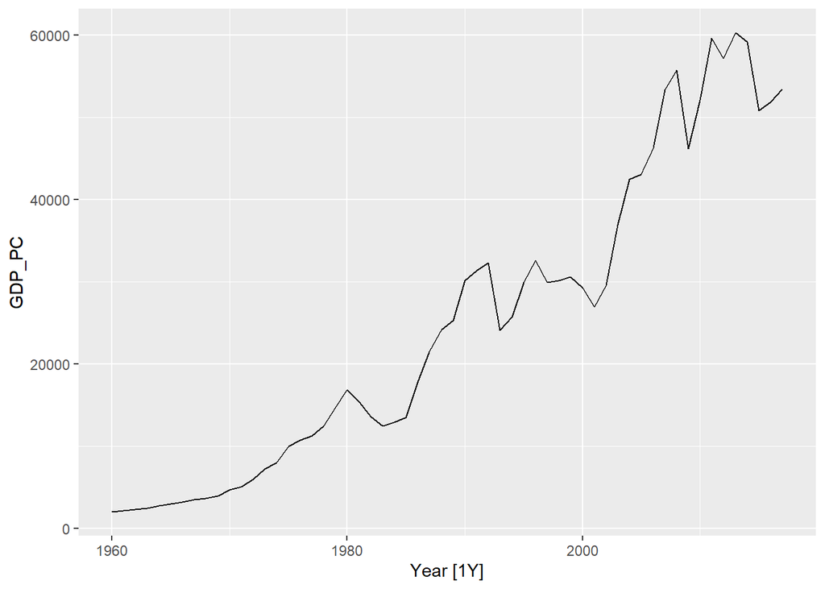

```r
gdppc %>%
  filter(Country == "Sweden") %>%
  autoplot(GDP_PC)
```

## 2.3 Define a model

The fable package has a number of different modeling method. Here we will use a linear time trend model

```r
timeSeries_lm <- TSLM(GDP_PC ~ trend())
```

## 2.4 Train / Fit the model

```r
timeSeries_lm_fit <- gdppc %>% model(timeSeries_lm)
timeSeries_lm_fit
```

```
## # A mable: 263 x 2
## # Key:     Country [263]
##    Country             timeSeries_lm
##    <fct>                     <model>
##  1 Afghanistan                <TSLM>
##  2 Albania                    <TSLM>
##  3 Algeria                    <TSLM>
##  4 American Samoa             <TSLM>
##  5 Andorra                    <TSLM>
##  6 Angola                     <TSLM>
##  7 Antigua and Barbuda        <TSLM>
##  8 Arab World                 <TSLM>
##  9 Argentina                  <TSLM>
## 10 Armenia                    <TSLM>
## # ℹ 253 more rows
```

```r
timeSeries_lm_fit %>% filter(Country =="Canada") %>% report()
```

```
## Series: GDP_PC
## Model: TSLM
##
## Residuals:
##     Min      1Q  Median      3Q     Max
## -8223.9 -2692.9  -719.9  2497.9 11692.7
##
## Coefficients:
##             Estimate Std. Error t value Pr(>|t|)
## (Intercept) -5819.97    1324.66  -4.394 5.02e-05 ***
## trend()       888.64      39.05  22.755  < 2e-16 ***
## ---
## Signif. codes:  0 '***' 0.001 '**' 0.01 '*' 0.05 '.' 0.1 ' ' 1
##
## Residual standard error: 4979 on 56 degrees of freedom
## Multiple R-squared: 0.9024,  Adjusted R-squared: 0.9007
## F-statistic: 517.8 on 1 and 56 DF, p-value: < 2.22e-16
```

## 2.5 Produc Forecast

```r
timeSeries_lm_fit %>% forecast(h = 3)
```

```
## # A fable: 789 x 5 [1Y]
## # Key:     Country, .model [263]
##    Country        .model         Year           GDP_PC  .mean
##    <fct>          <chr>         <dbl>           <dist>  <dbl>
##  1 Afghanistan    timeSeries_lm  2018     N(526, 9653)   526.
##  2 Afghanistan    timeSeries_lm  2019     N(534, 9689)   534.
##  3 Afghanistan    timeSeries_lm  2020     N(542, 9727)   542.
##  4 Albania        timeSeries_lm  2018  N(4716, 476419)  4716.
##  5 Albania        timeSeries_lm  2019  N(4867, 481086)  4867.
##  6 Albania        timeSeries_lm  2020  N(5018, 486012)  5018.
##  7 Algeria        timeSeries_lm  2018  N(4410, 643094)  4410.
##  8 Algeria        timeSeries_lm  2019  N(4489, 645311)  4489.
##  9 Algeria        timeSeries_lm  2020  N(4568, 647602)  4568.
## 10 American Samoa timeSeries_lm  2018 N(12491, 652926) 12491.
## # ℹ 779 more rows
```

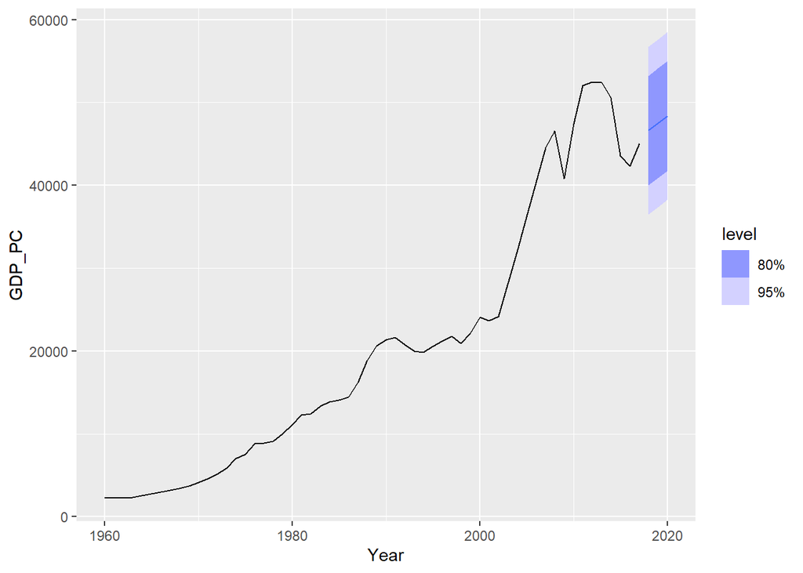

```r
timeSeries_lm_fit %>% forecast(h = 3) %>%
  filter(Country == "Canada") %>%
  autoplot(gdppc)
```

# 3 Simple Forecasting Methods

First we filter the time series using the filter_index method from the tsibble package

```r
bricks <- aus_production %>%
  filter_index("1970 Q1" ~ "2004 Q4") %>%
  select(Bricks)
```

## 3.1 Mean Method

Future values are set to the historical average

## 3.2 Naive Method

Sets all future values to the last historical value

## 3.3 Seasonal Naive Method

Sets future value to a lagged value of a seasonal series

## 3.4 Drift method

Similar to the Naive Method, but the forecast is allowed to increase or decrease with the overall trend

## 3.5 Example Australian Beer Production

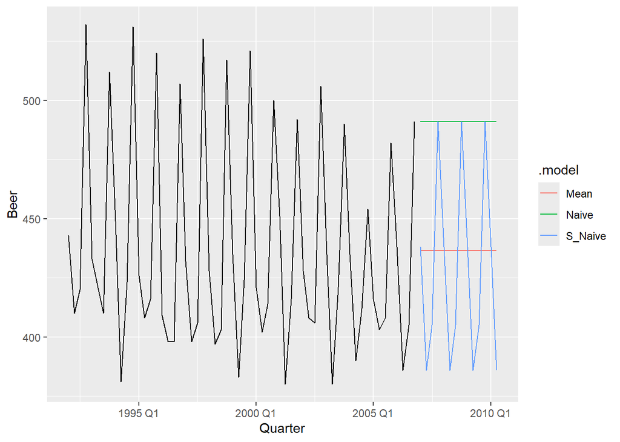

```r
train <- aus_production %>%
  filter_index("1992 Q1" ~ "2006 Q4")

## Fit models

beer_fit <- train %>%
  model(
    Mean = MEAN(Beer),
    Naive = NAIVE(Beer),
    S_Naive = SNAIVE(Beer)
  )

## Forecast for 14 quarters

beer_fc <- beer_fit %>% forecast(h = 14)

## Plot forecast against actual

beer_fc %>% autoplot(train, level = NULL)
```

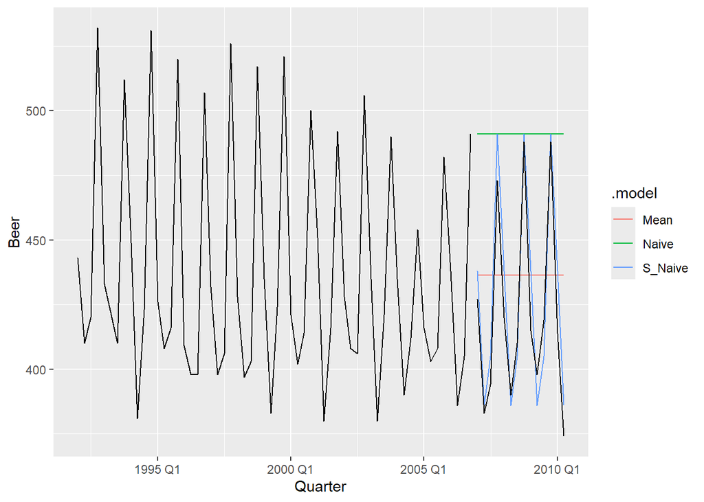

```r
beer_fc %>% autoplot(train, level = NULL) +
  autolayer(
    filter_index(aus_production, "2007 Q1" ~ .),
    colour = "black"
  )
```

## 3.6 Fitted and Residuals

The fable package works with the broom methods.

```r
augment(beer_fit)
```

```
## # A tsibble: 180 x 6 [1Q]
## # Key:       .model [3]
##    .model Quarter  Beer .fitted .resid .innov
##    <chr>    <qtr> <dbl>   <dbl>  <dbl>  <dbl>
##  1 Mean   1992 Q1   443    436.   6.55   6.55
##  2 Mean   1992 Q2   410    436. -26.4  -26.4
##  3 Mean   1992 Q3   420    436. -16.4  -16.4
##  4 Mean   1992 Q4   532    436.  95.6   95.6
##  5 Mean   1993 Q1   433    436.  -3.45  -3.45
##  6 Mean   1993 Q2   421    436. -15.4  -15.4
##  7 Mean   1993 Q3   410    436. -26.4  -26.4
##  8 Mean   1993 Q4   512    436.  75.6   75.6
##  9 Mean   1994 Q1   449    436.  12.6   12.6
## 10 Mean   1994 Q2   381    436. -55.4  -55.4
## # ℹ 170 more rows
```

## 3.7 Residual Diagnostics

1. no correlation between residuals
2. zero mean residuals
3. constant variance
4. Normally distributed

## 3.8 Example: Predicting Google daily closing price

```r
google_stock <- gafa_stock %>%
  filter(Symbol == "GOOG", year(Date) >= 2015) %>%
  mutate(day = row_number()) %>%
  update_tsibble(index = day, regular = TRUE)

# Filter the year of interest
google_2015 <- google_stock |> filter(year(Date) == 2015)
```

```r
google_aug <- google_2015 %>%
  model(NAIVE(Close)) %>%
  augment()
```

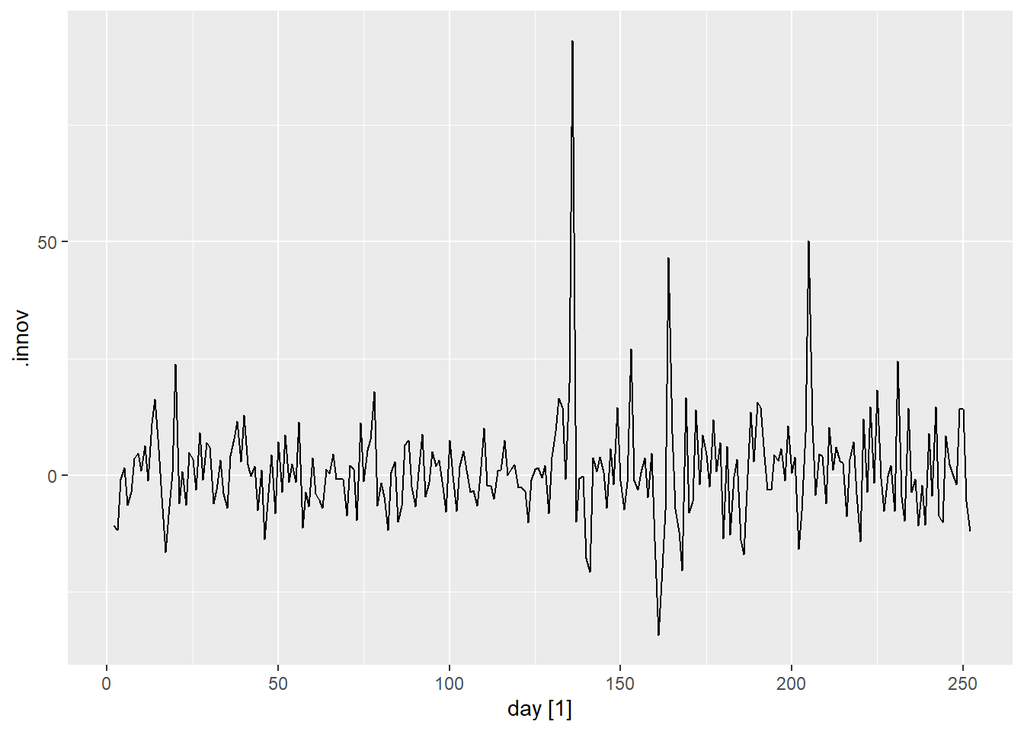

```r
autoplot(google_aug, .innov)
```

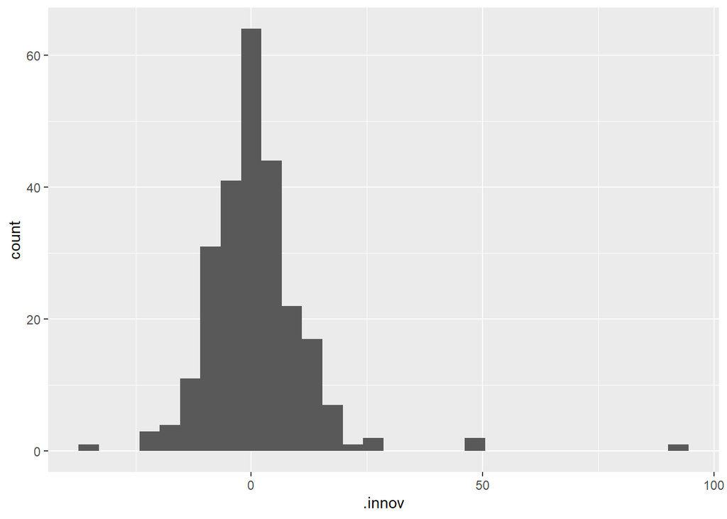

```r
google_aug %>%
  ggplot(aes(x = .innov)) +
  geom_histogram()
```

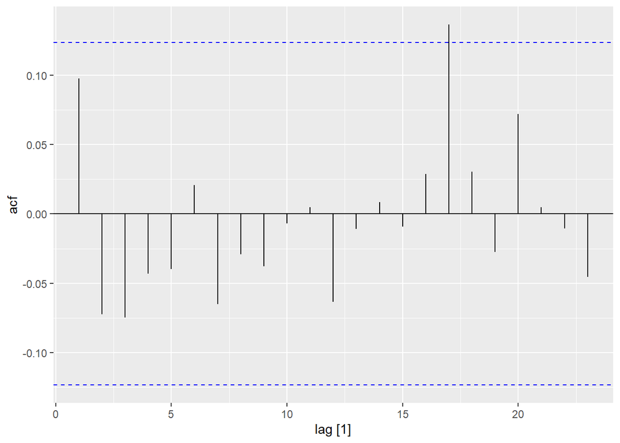

```r
google_aug %>% ACF(.innov) %>% autoplot()
```

Plots 1 and 3 of the previous three plots demonstrate points 1 and 2 in the introduction. The following code block produces a layout with all of these diagnostic plots.

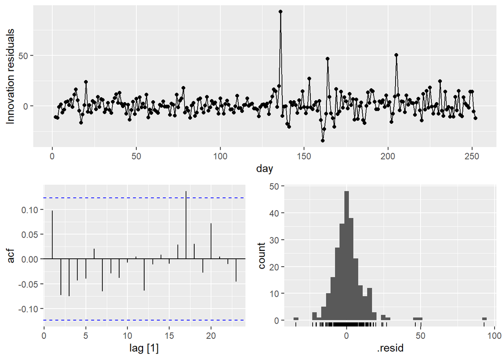

```r
google_2015 %>% model(NAIVE(Close)) %>% gg_tsresiduals()
```

## 3.9 Portmeanteau Tests for AC

Box Pierce

```r
google_aug %>% features(.innov, box_pierce, lag = 10)
```

```
## # A tibble: 1 × 4
##   Symbol .model       bp_stat bp_pvalue
##   <chr>  <chr>          <dbl>     <dbl>
## 1 GOOG   NAIVE(Close)    7.74     0.654
```

Ljung_Box

```r
google_aug %>% features(.innov, ljung_box, lag = 10)
```

```
## # A tibble: 1 × 4
##   Symbol .model       lb_stat lb_pvalue
##   <chr>  <chr>          <dbl>     <dbl>
## 1 GOOG   NAIVE(Close)    7.91     0.637
```

Looking at the drift method and autocorelation tests in a simplified modeling flow.

```r
google_fit_drift <- google_2015 %>% model(RW(Close ~ drift()))
google_fit_drift %>% tidy()
```

```
## # A tibble: 1 × 7
##   Symbol .model              term  estimate std.error statistic p.value
##   <chr>  <chr>               <chr>    <dbl>     <dbl>     <dbl>   <dbl>
## 1 GOOG   RW(Close ~ drift()) b        0.944     0.705      1.34   0.182
```

```r
google_fit_drift %>% augment() %>% features(.innov, ljung_box, lag = 10)
```

```
## # A tibble: 1 × 4
##   Symbol .model              lb_stat lb_pvalue
##   <chr>  <chr>                 <dbl>     <dbl>
## 1 GOOG   RW(Close ~ drift())    7.91     0.637
```

# 4 Distributional Forecasts and Prediction Intervals

- Most time series models produce normally distributed forecasts

## 4.1 Prediction Intervals

- used to express a probability distribution of where a forecast may land within a given coverage

## 4.2 One Step Prediction Intervals

When forecasting one step ahead the standard deviation can be estimated using the SD of the residuals.

## 4.3 Benchmark Methods

The four benchmark methods have simple analytical formulas for h-step prediction standard deviations.

Prediction intervals are easily computed using the fable packages hilo() method

```r
google_2015 %>%
  model(NAIVE(Close)) %>%
  forecast(h = 10) %>%
  hilo()
```

```
## # A tsibble: 10 x 7 [1]
## # Key:       Symbol, .model [1]
##    Symbol .model         day        Close .mean                  `80%`
##    <chr>  <chr>        <dbl>       <dist> <dbl>                 <hilo>
##  1 GOOG   NAIVE(Close)   253  N(759, 125)  759. [744.5400, 773.2200]80
##  2 GOOG   NAIVE(Close)   254  N(759, 250)  759. [738.6001, 779.1599]80
##  3 GOOG   NAIVE(Close)   255  N(759, 376)  759. [734.0423, 783.7177]80
##  4 GOOG   NAIVE(Close)   256  N(759, 501)  759. [730.1999, 787.5601]80
##  5 GOOG   NAIVE(Close)   257  N(759, 626)  759. [726.8147, 790.9453]80
##  6 GOOG   NAIVE(Close)   258  N(759, 751)  759. [723.7543, 794.0058]80
##  7 GOOG   NAIVE(Close)   259  N(759, 876)  759. [720.9399, 796.8202]80
##  8 GOOG   NAIVE(Close)   260 N(759, 1002)  759. [718.3203, 799.4397]80
##  9 GOOG   NAIVE(Close)   261 N(759, 1127)  759. [715.8599, 801.9001]80
## 10 GOOG   NAIVE(Close)   262 N(759, 1252)  759. [713.5329, 804.2272]80
## # ℹ 1 more variable: `95%` <hilo>
```

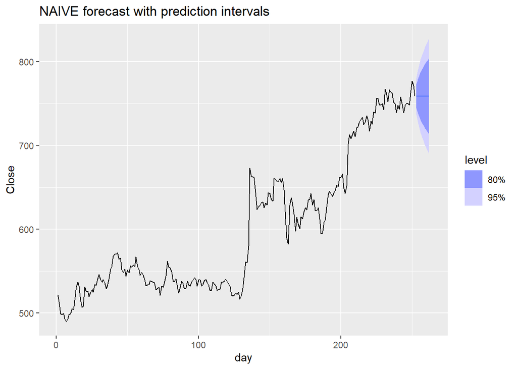

```r
google_2015 %>%
  model(NAIVE(Close)) %>%
  forecast(h = 10) %>%
  autoplot(google_2015) +
  labs(title = "NAIVE forecast with prediction intervals")
```

## Prediction Intervals from Bootstrapped Residuls

If normally distributed residuals can not be assumed we can use a bootstrap method to estimate the standard deviation by drawing samples from past residuals

We can perform a bootstrap using the generate() function

```r
library(fabletools)
fit_google_Naive <- google_2015 %>%
  model(NAIVE(Close))

google_Naive_boot <- fit_google_Naive %>%
  fabletools::generate(h = 30, times = 5, bootstrap = TRUE)
```

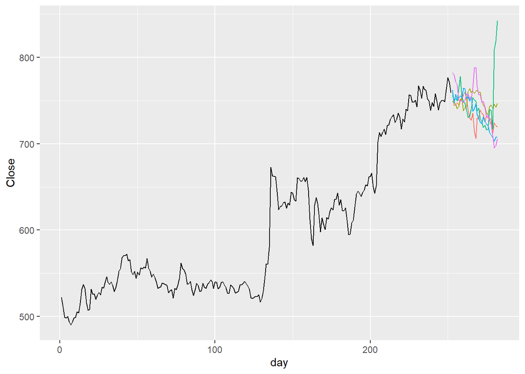

```r
google_2015 %>%
  ggplot(aes(x = day)) +
  geom_line(aes(y = Close)) +
  geom_line(aes(y = .sim, color = as.factor(.rep)), data = google_Naive_boot) +
  guides(color = "none")
```

After generating bootstrap sample mean pathways we can generate prediction interval based off of each pathway generated. We can use forecast directly to generate bootstrap samples. We can also control the bootstrap parameters in forecast.

```r
forecast_boot <- fit_google_Naive %>% forecast(h = 30, bootstrap = TRUE)
forecast_boot
```

```
## # A fable: 30 x 5 [1]
## # Key:     Symbol, .model [1]
##    Symbol .model         day        Close .mean
##    <chr>  <chr>        <dbl>       <dist> <dbl>
##  1 GOOG   NAIVE(Close)   253 sample[5000]  759.
##  2 GOOG   NAIVE(Close)   254 sample[5000]  759.
##  3 GOOG   NAIVE(Close)   255 sample[5000]  759.
##  4 GOOG   NAIVE(Close)   256 sample[5000]  759.
##  5 GOOG   NAIVE(Close)   257 sample[5000]  759.
##  6 GOOG   NAIVE(Close)   258 sample[5000]  759.
##  7 GOOG   NAIVE(Close)   259 sample[5000]  759.
##  8 GOOG   NAIVE(Close)   260 sample[5000]  759.
##  9 GOOG   NAIVE(Close)   261 sample[5000]  759.
## 10 GOOG   NAIVE(Close)   262 sample[5000]  759.
## # ℹ 20 more rows
```

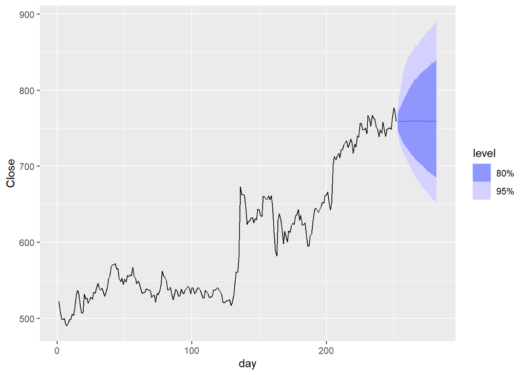

```r
autoplot(forecast_boot, google_2015)
```

```r
str(forecast_boot$Close[10])
```

```
## dist [1:1]
## $ :List of 1
##  ..$ x: num [1:5000] 711 730 765 733 754 ...
##  ..- attr(*, "class")= chr [1:2] "dist_sample" "dist_default"
## @ vars: chr "Close"
```

I wanted to unlist one of the model objects. This Stack Ex was helpful https://stackoverflow.com/questions/73973322/r-fable-how-to-access-distribution-object-elements

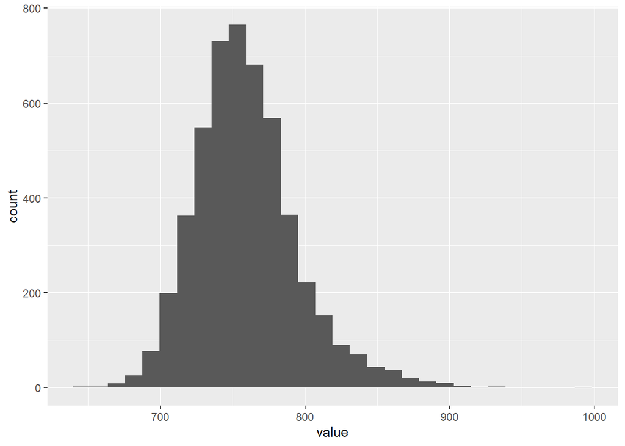

```r
samp10 <- forecast_boot$Close[10]
params <- distributional::parameters(samp10) %>% unlist(use.names = FALSE) %>% as_tibble()

params %>% ggplot(aes(x = value)) + geom_histogram()
```

```r
# Code used for parameters

parameters.distribution <- function(x, ...) {
  x <- lapply(vec_data(x), parameters)
  x <- lapply(x, function(z) data_frame(!!!z, .name_repair = "minimal"))
  vec_rbind(!!!x)
}
```

## 4.4 Forecasting Using Transformations

When back transforming a forecast typically the transformed forecast point estimate is a median. This can be adjusted by applying a transformation that accounts for this distributional bias. This is called a Bias Adjusted transformation.

Example: Difference between median and mean of a transformed forecast Note: Fable will automatically back transform and bias correct reported means

```r
transform_ex <- prices %>%
  filter(!is.na(eggs)) %>%
  model(RW(log(eggs) ~ drift())) %>%
  forecast(h = 50)
transform_ex
```

```
## # A fable: 50 x 4 [1Y]
## # Key:     .model [1]
##    .model                   year             eggs .mean
##    <chr>                   <dbl>           <dist> <dbl>
##  1 RW(log(eggs) ~ drift())  1994 t(N(4.1, 0.018))  61.8
##  2 RW(log(eggs) ~ drift())  1995 t(N(4.1, 0.036))  61.4
##  3 RW(log(eggs) ~ drift())  1996 t(N(4.1, 0.055))  61.0
##  4 RW(log(eggs) ~ drift())  1997 t(N(4.1, 0.074))  60.6
##  5 RW(log(eggs) ~ drift())  1998 t(N(4.1, 0.093))  60.2
##  6 RW(log(eggs) ~ drift())  1999    t(N(4, 0.11))  59.8
##  7 RW(log(eggs) ~ drift())  2000    t(N(4, 0.13))  59.4
##  8 RW(log(eggs) ~ drift())  2001    t(N(4, 0.15))  59.0
##  9 RW(log(eggs) ~ drift())  2002    t(N(4, 0.18))  58.6
## 10 RW(log(eggs) ~ drift())  2003     t(N(4, 0.2))  58.3
## # ℹ 40 more rows
```

I plot this in three steps to show how autoplot detects input and changes the plot type even if not directly used in the aesthetics

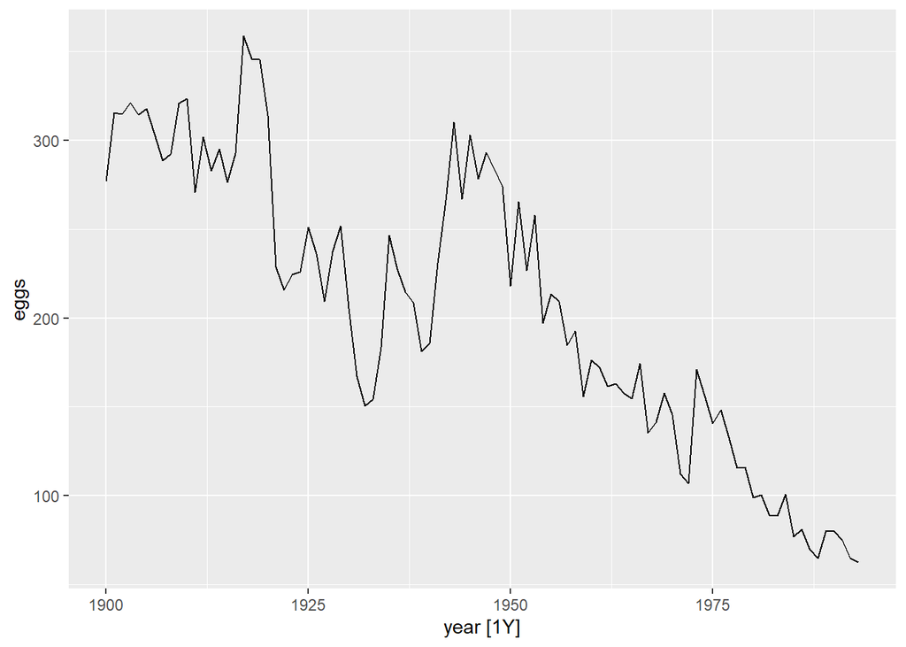

```r
transform_ex <- transform_ex %>% mutate(.median = median(eggs))

autoplot(prices %>% filter(!is.na(eggs)), level = 80)
```

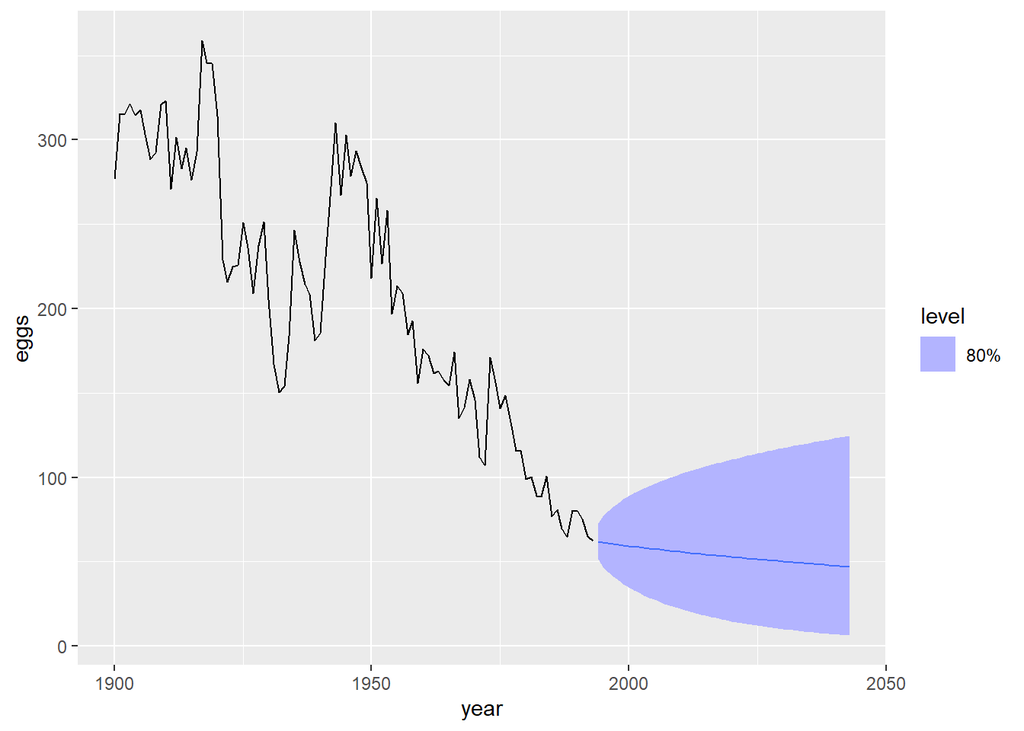

```r
transform_ex %>% autoplot(prices %>% filter(!is.na(eggs)), level = 80)
```

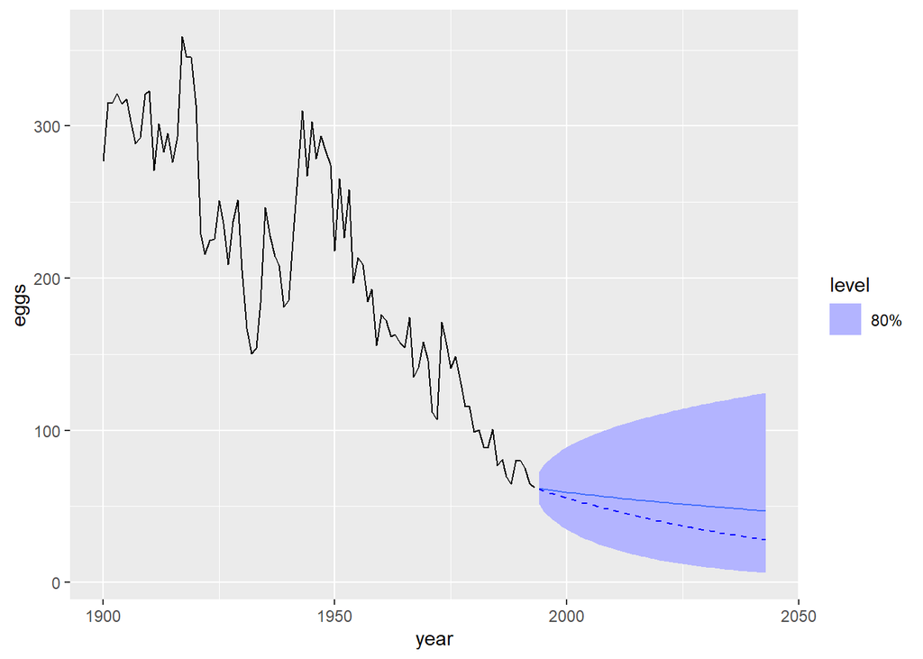

```r
transform_ex %>%
  autoplot(prices %>% filter(!is.na(eggs)), level = 80) +
  geom_line(aes(y = .median), data = transform_ex, linetype = 2, color = "blue")
```

# Forecasting with Decomposition

To forecast a decoposed series we forecast the seasonal and seasonally adjused (Trend + Remainder) seperately

## 4.5 Example: US Retail Employment

```r
us_retail_employment <- us_employment |>
  filter(year(Month) >= 1990, Title == "Retail Trade")

# produce seasonally adjusted data using decomposition

rEmp_dcmp <- us_retail_employment %>%
  model(STL(Employed ~ trend(window = 7), robust = TRUE)) %>%
  components() %>%
  select(-.model)
```

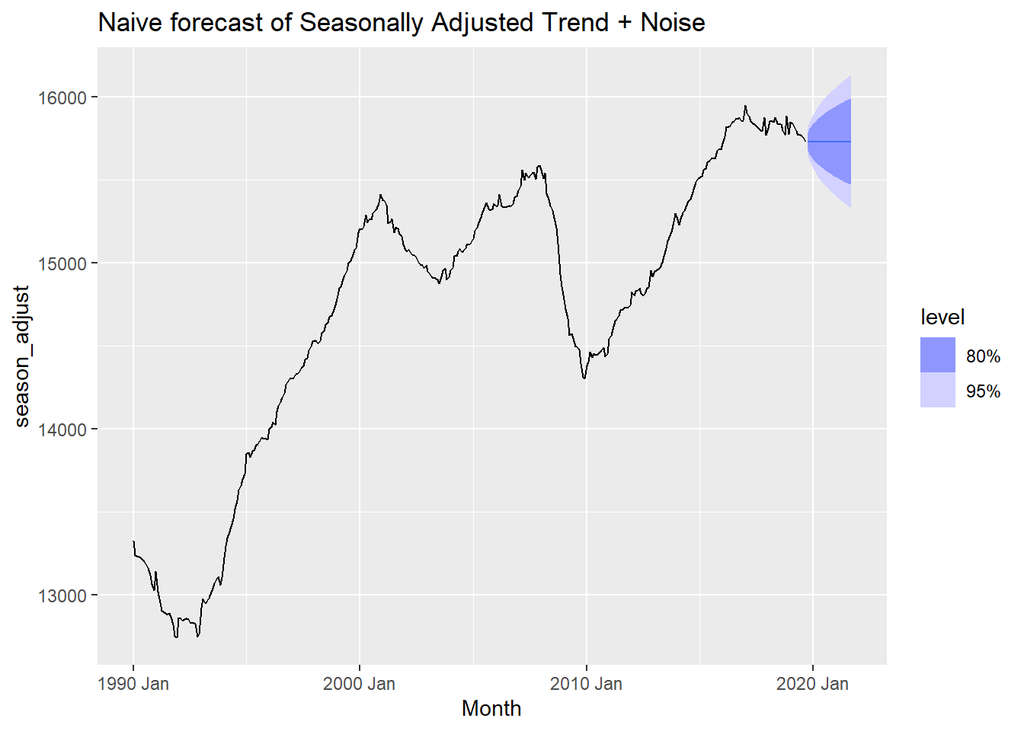

```r
# NAIVE forecast of seasonally adjusted data

rEmp_dcmp %>%
  model(NAIVE(season_adjust)) %>%
  forecast() %>%
  autoplot(rEmp_dcmp) +
  labs(title = "Naive forecast of Seasonally Adjusted Trend + Noise")
```

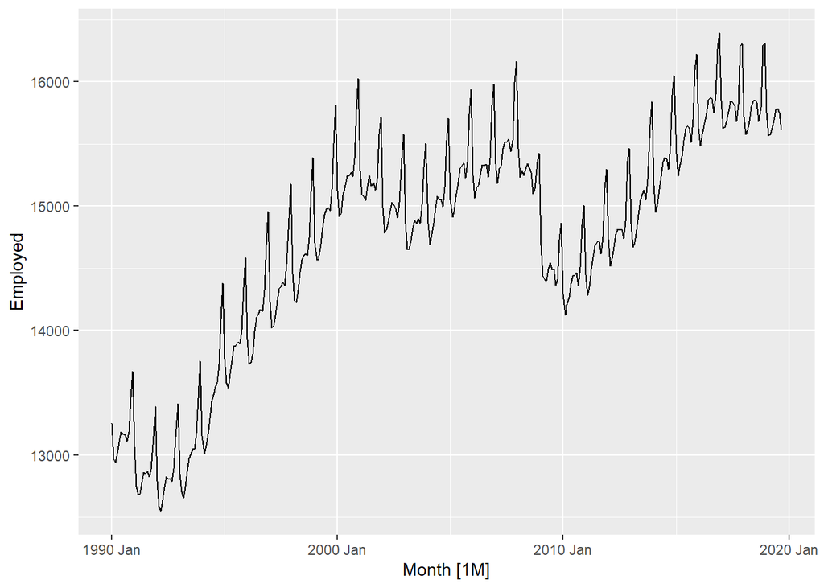

```r
us_retail_employment %>% autoplot(Employed)
```

These steps can be combined using the decomposition_model() function. In this example we use a seasonal Naive forecast of the sesonal component The seasonal component is forecasted by default using Seasonal Naive, and could be specified as a third argument.

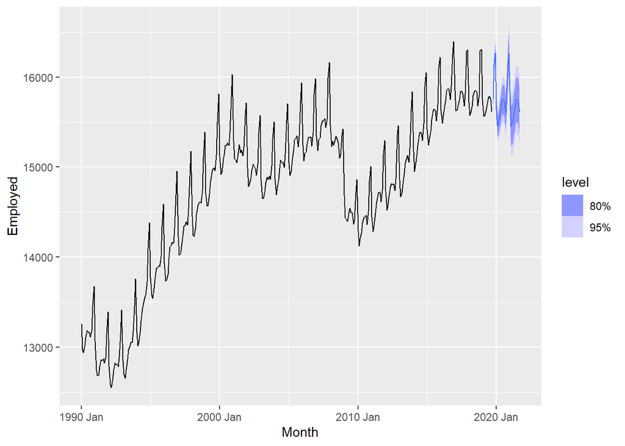

```r
fit_seasonal_decomp <- us_retail_employment %>%
  model(stlf = decomposition_model(
    STL(Employed ~ trend(window = 7), robust = TRUE),
    NAIVE(season_adjust)
  ))

fit_seasonal_decomp %>%
  forecast() %>%
  autoplot(us_retail_employment)
```

# 5 Evaluating Point Forecast Accuracy

## 5.1 Functions to subset a time series

I’m familiar with most of the examples, but the code block below extracts the last 20 observations and is novel to me

```r
aus_production %>% slice(n()-19:0)
```

```
## # A tsibble: 20 x 7 [1Q]
##    Quarter  Beer Tobacco Bricks Cement Electricity   Gas
##      <qtr> <dbl>   <dbl>  <dbl>  <dbl>       <dbl> <dbl>
##  1 2005 Q3   408      NA     NA   2340       56043   221
##  2 2005 Q4   482      NA     NA   2265       54992   180
##  3 2006 Q1   438      NA     NA   2027       57112   171
##  4 2006 Q2   386      NA     NA   2278       57157   224
##  5 2006 Q3   405      NA     NA   2427       58400   233
##  6 2006 Q4   491      NA     NA   2451       56249   192
##  7 2007 Q1   427      NA     NA   2140       56244   187
##  8 2007 Q2   383      NA     NA   2362       55036   234
##  9 2007 Q3   394      NA     NA   2536       59806   245
## 10 2007 Q4   473      NA     NA   2562       56411   205
## 11 2008 Q1   420      NA     NA   2183       59118   194
## 12 2008 Q2   390      NA     NA   2558       56660   229
## 13 2008 Q3   410      NA     NA   2612       64067   249
## 14 2008 Q4   488      NA     NA   2373       59045   203
## 15 2009 Q1   415      NA     NA   1963       58368   196
## 16 2009 Q2   398      NA     NA   2160       57471   238
## 17 2009 Q3   419      NA     NA   2325       58394   252
## 18 2009 Q4   488      NA     NA   2273       57336   210
## 19 2010 Q1   414      NA     NA   1904       58309   205
## 20 2010 Q2   374      NA     NA   2401       58041   236
```

## 5.2 Common Error Measures

- Forecast Errors
- Scale Dependent Errors **

## 5.3 Examples: Benchmark Forecasts, Accuracy and Forecast Errors